# Caso Pŕactico Final

We will use the credit approval dataset available at https://archive.ics.uci.edu/ml/datasets/Credit+Approval. The data can also be loaded from the folder under the filename “crx.data”. Information about the dataset can be found at https://archive.ics.uci.edu/ml/machine-learning-databases/credit-screening/crx.names y in the following:

```
  1. Title: Credit Approval

  2. Sources:
      (confidential)
      Submitted by quinlan@cs.su.oz.au

  3.  Past Usage:

      See Quinlan,
      * "Simplifying decision trees", Int J Man-Machine Studies 27,
        Dec 1987, pp. 221-234.
      * "C4.5: Programs for Machine Learning", Morgan Kaufmann, Oct 1992

  4.  Relevant Information:

      This file concerns credit card applications.  All attribute names
      and values have been changed to meaningless symbols to protect
      confidentiality of the data.

      This dataset is interesting because there is a good mix of
      attributes -- continuous, nominal with small numbers of
      values, and nominal with larger numbers of values.  There
      are also a few missing values.

  5.  Number of Instances: 690

  6.  Number of Attributes: 15 + class attribute

  7.  Attribute Information:

      A1:   b, a.
      A2:   continuous.
      A3:   continuous.
      A4:   u, y, l, t.
      A5:   g, p, gg.
      A6:   c, d, cc, i, j, k, m, r, q, w, x, e, aa, ff.
      A7:   v, h, bb, j, n, z, dd, ff, o.
      A8:   continuous.
      A9:   t, f.
      A10:  t, f.
```

[output cut: 8 more lines]

```
      37 cases (5%) have one or more missing values.  The missing
      values from particular attributes are:

      A1:  12
      A2:  12
      A4:   6
      A5:   6
      A6:   9
      A7:   9
      A14: 13

  9.  Class Distribution

      +: 307 (44.5%)
      -: 383 (55.5%)
```

## Tasks

1. Load data. Do an inspection of the distribution of the variables and present them visually. Make pertinent observations. What variables are the best for separating the data?
2. Prepare the dataset and impute missing values using the `missForest` library.
3. Split the dataset into train and test, taking the first 590 rows as train, and the last 100 as test.
4. Train a logistic regression model with Ridge and Lasso selecting the best model based on **AUC**. Give the metrics for the test data.
5. Show the log odds for the predictive variables.
6. If for every true positive we win 100 euros, and for every false positive we lose 20 euros, how much money will we make using the confusion matrix for the model with the best **AUC**?

**Task 1**

Load libraries

```r
library(dplyr)
library(readr)
library(ggplot2)
library(missForest)
library(corrplot)
library(caret)
library(glmnet)
```

Import data

```r
df <- read_csv("crx.data", col_names = FALSE, col_types = "fddffffdlldlfddc")
```

```
25 parsing failures.
row col expected actual       file
 72 X14 a double      ? 'crx.data'
 84 X2  a double      ? 'crx.data'
 87 X2  a double      ? 'crx.data'
 93 X2  a double      ? 'crx.data'
 98 X2  a double      ? 'crx.data'
... ... ........ ...... ..........
See problems(...) for more details.
```

```r
head(df)
```

| X1 | X2 | X3 | X4 | X5 | X6 | X7 | X8 | X9 | X10 | X11 | X12 | X13 | X14 | X15 | X16 |
| --- | --- | --- | --- | --- | --- | --- | --- | --- | --- | --- | --- | --- | --- | --- | --- |
| b | 30.83 | 0.000 | u | g | w | v | 1.25 | TRUE | TRUE | 1 | FALSE | g | 202 | 0 | + |
| a | 58.67 | 4.460 | u | g | q | h | 3.04 | TRUE | TRUE | 6 | FALSE | g | 43 | 560 | + |
| a | 24.50 | 0.500 | u | g | q | h | 1.50 | TRUE | FALSE | 0 | FALSE | g | 280 | 824 | + |
| b | 27.83 | 1.540 | u | g | w | v | 3.75 | TRUE | TRUE | 5 | TRUE | g | 100 | 3 | + |
| b | 20.17 | 5.625 | u | g | w | v | 1.71 | TRUE | FALSE | 0 | FALSE | s | 120 | 0 | + |
| b | 32.08 | 4.000 | u | g | m | v | 2.50 | TRUE | FALSE | 0 | TRUE | g | 360 | 0 | + |

```r
summary(df[, 1:10])
```

```
 X1            X2              X3         X4       X5            X6            X7            X8             X9             X10
 b:468   Min.   :13.75   Min.   : 0.000   u:519   g :519   c      :137   v      :399   Min.   : 0.000   Mode :logical   Mode :logical
 a:210   1st Qu.:22.60   1st Qu.: 1.000   y:163   p :163   q      : 78   h      :138   1st Qu.: 0.165   FALSE:329       FALSE:395
 ?: 12   Median :28.46   Median : 2.750   ?:  6   ? :  6   w      : 64   bb     : 59   Median : 1.000   TRUE :361       TRUE :295
         Mean   :31.57   Mean   : 4.759   l:  2   gg:  2   i      : 59   ff     : 57   Mean   : 2.223
         3rd Qu.:38.23   3rd Qu.: 7.207                    aa     : 54   ?      :  9   3rd Qu.: 2.625
         Max.   :80.25   Max.   :28.000                    ff     : 53   j      :  8   Max.   :28.500
         NA's   :12                                        (Other):245   (Other): 20
```

```r
summary(df[, 11:16])
```

```
      X11          X12          X13          X14            X15               X16
 Min.   : 0.0   Mode :logical   g:625   Min.   :   0   Min.   :     0.0   Length:690
 1st Qu.: 0.0   FALSE:374       s: 57   1st Qu.:  75   1st Qu.:     0.0   Class :character
 Median : 0.0   TRUE :316       p:  8   Median : 160   Median :     5.0   Mode  :character
 Mean   : 2.4                           Mean   : 184   Mean   :  1017.4
 3rd Qu.: 3.0                           3rd Qu.: 276   3rd Qu.:   395.5
 Max.   :67.0                           Max.   :2000   Max.   :100000.0
                                        NA's   :13
```

Here we see that some factorised columns (X1, X4, X5, X6 and X7) have “?” as a value. The question mark is not one of the possible levels as described above in the attribute information. These will need to be converted to NA’s and then imputed. In addition, we find that in column X2, 12 value’s are described as NA as well as in X14, 13 values are found to be missing, confirming information provided above in the Missing Attribute Values section.

```r
sum(df$X6 == "?") # Confirm that column X6 contains missing values in the form of "?"
```

```
[1] 9
```

Column X16 is of a binary format, and so we can recode this column to reflect this. This is the attribute against which we want to later run a logistical regression, therefore recoding now means we won’t have issues down the line.

```r
df$X16 <- recode(df$X16, "+" = TRUE, "-" = FALSE)
```

Plot distrubtion of all variables

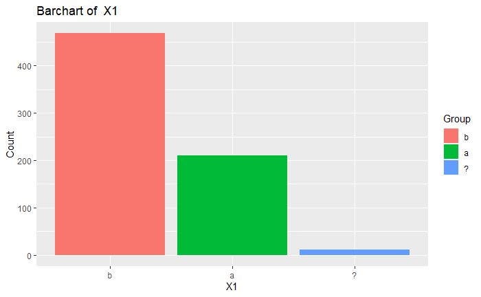

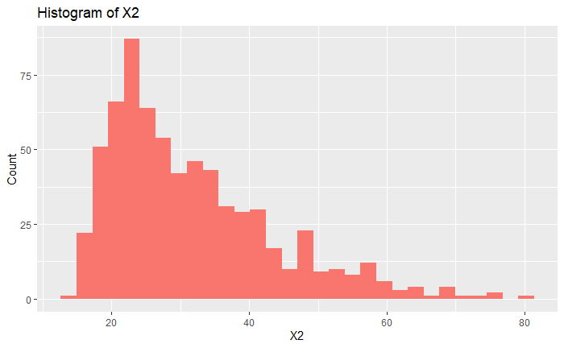

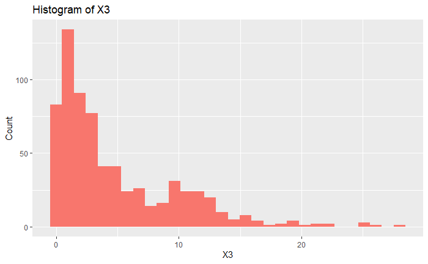

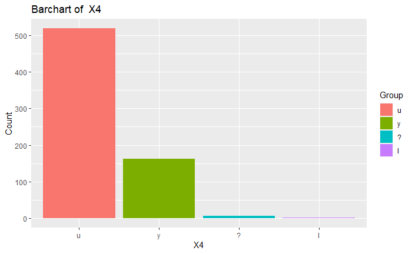

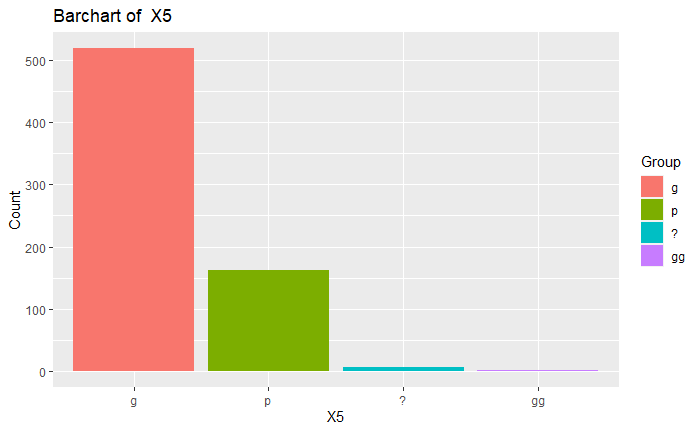

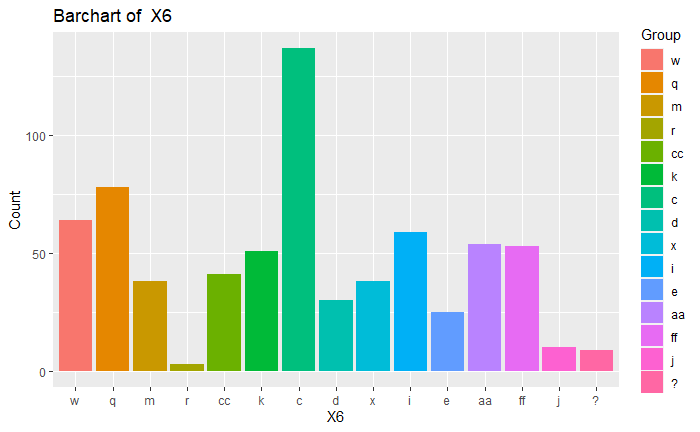

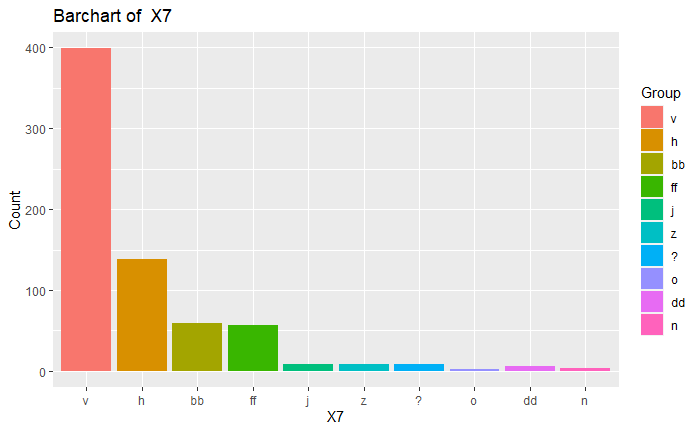

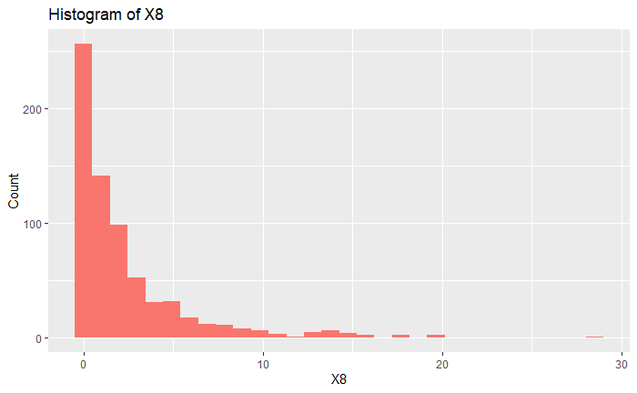

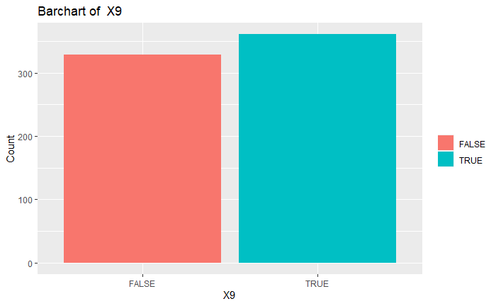

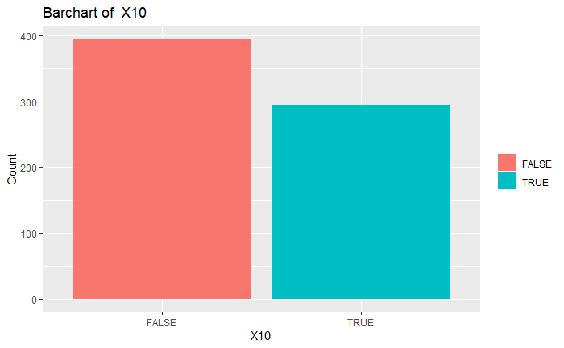

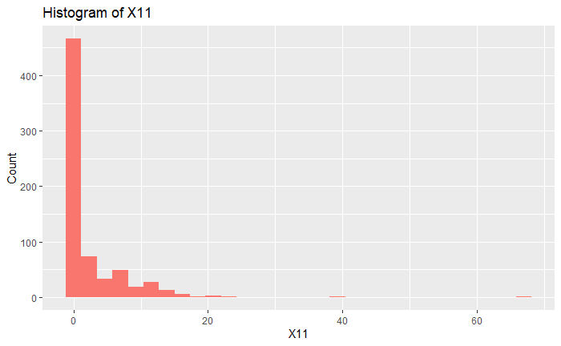

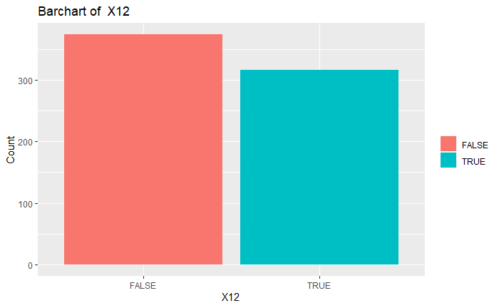

[4 more figures not shown]

```r
distributions <- function(dataframe) {
  for (col in 1:ncol(dataframe)) {
    if (class(dataframe[[col]]) == "factor") {
      plot <- ggplot(dataframe) +
        geom_bar(aes(x = dataframe[[col]],
                     fill = dataframe[[col]])) +
        labs(title = paste("Barchart of ", colnames(dataframe[col])),
             x = colnames(df[col]),
             y = "Count",
             fill = "Group")
    } else if (class(dataframe[[col]]) == "logical") {
      plot <- ggplot(dataframe) +
        geom_bar(aes(x = dataframe[[col]],
                     fill = dataframe[[col]])) +
        labs(title = paste("Barchart of ", colnames(dataframe[col])),
             x = colnames(df[col]),
             y = "Count") +
        theme(legend.title = element_blank())
    } else {
      # Histogram plotted for numeric variables
      plot <- ggplot(dataframe) +
        geom_histogram(aes(x = dataframe[[col]], fill = "red")) +
        labs(title = paste("Histogram of", colnames(dataframe[col])),
             x = colnames(df[col]),
             y = "Count") +
        theme(legend.position = "none")
    }
  plot <- print(plot)
  }
}

distributions(df)
```

plot each variable against class attribute (X16)

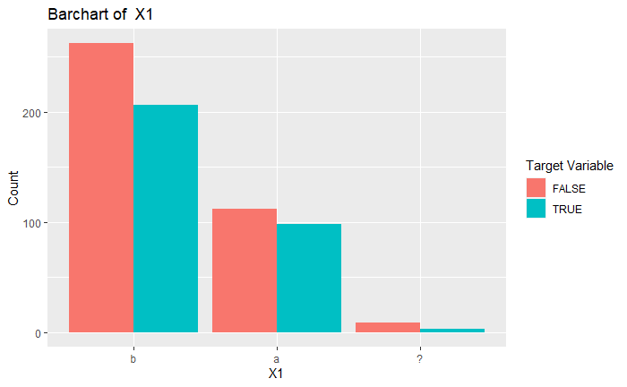

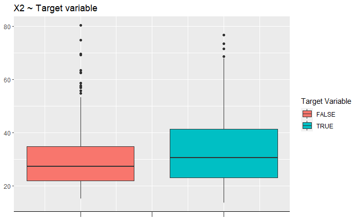

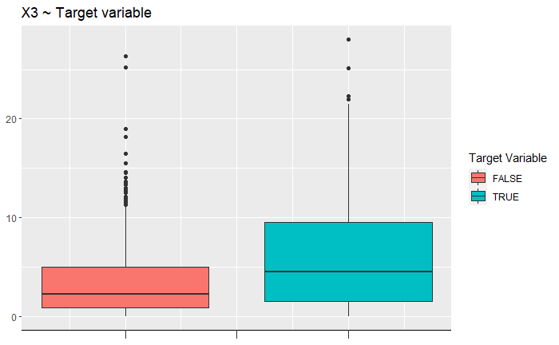

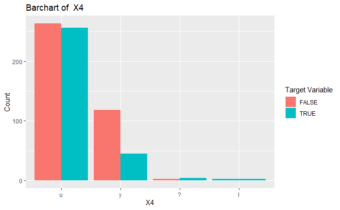

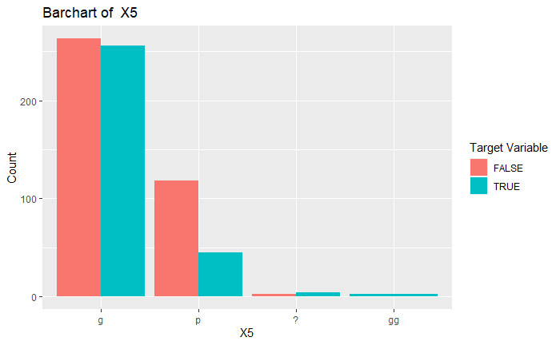

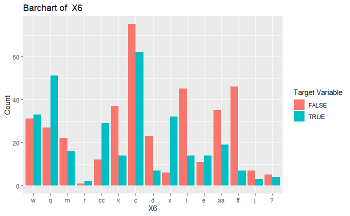

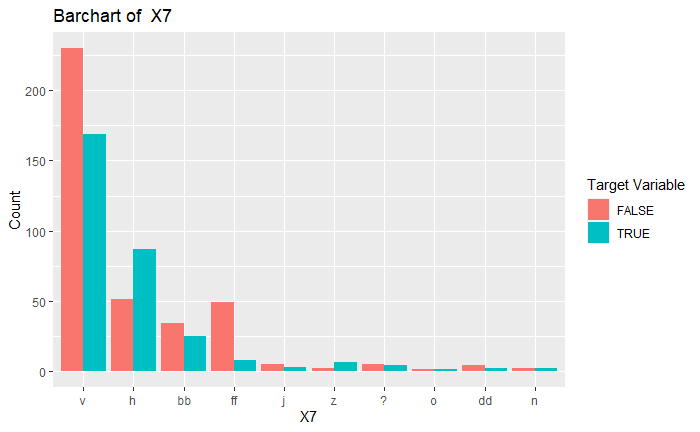

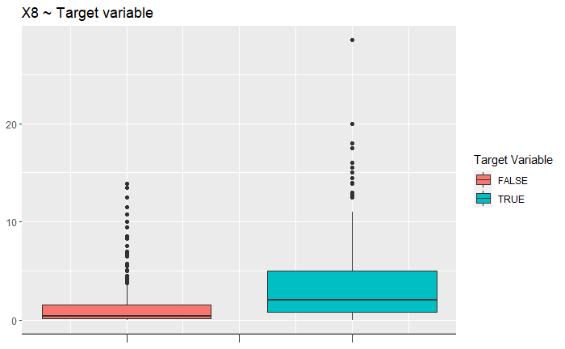

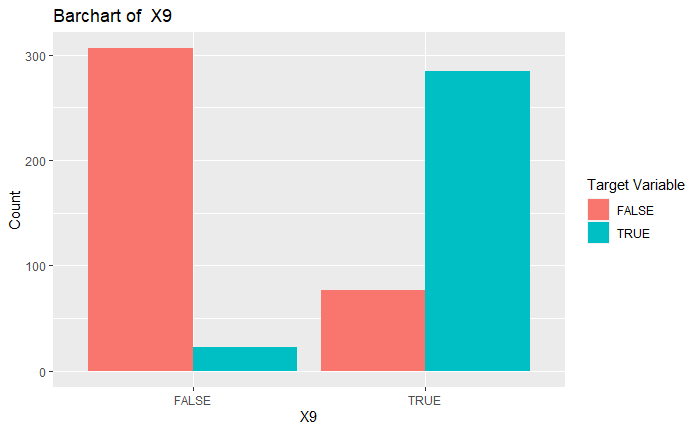

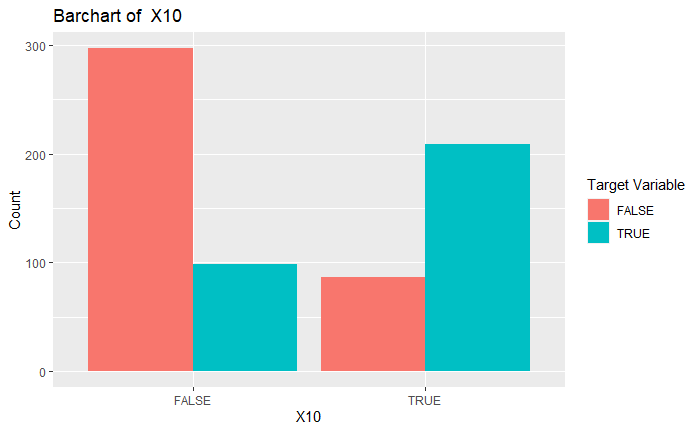

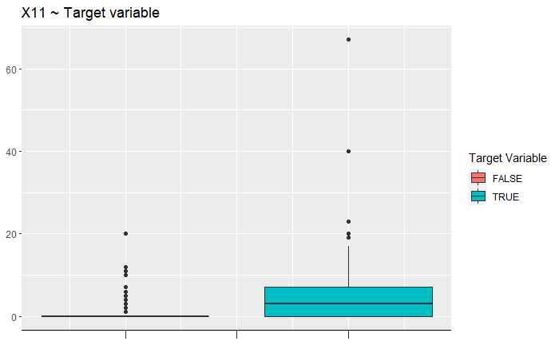

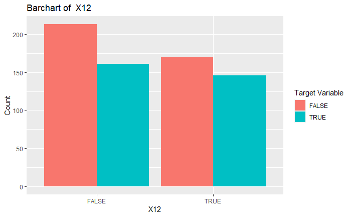

[3 more figures not shown]

```r
plot_variables_vs_target <- function(dataframe, target_column) {
  for (col in 1:ncol(dataframe)) {
    if (colnames(dataframe[col]) == "X16") {
      next
    } else {
      if (class(dataframe[[col]]) == "factor") {
        plot <- ggplot(dataframe, aes(x = dataframe[[col]],
                                      fill = as.factor(target_column))) +
          geom_bar(position = "dodge") +
          labs(title = paste("Barchart of ", colnames(dataframe[col])),
               x = colnames(df[col]),
               y = "Count",
               fill = "Target Variable")
      } else if (class(dataframe[[col]]) == "logical") {
        plot <- ggplot(dataframe, aes(x = dataframe[[col]],
                                      fill = as.factor(target_column))) +
          geom_bar(position = "dodge") +
          labs(title = paste("Barchart of ", colnames(dataframe[col])),
               x = colnames(df[col]),
               y = "Count",
               fill = "Target Variable")
      } else {
        plot <- ggplot(df, aes(x = dataframe[[col]], fill = as.factor(target_column))) +
            geom_boxplot(position = position_dodge(1)) +
            coord_flip() +
            labs(title = paste(colnames(dataframe[col]), "~ Target variable"),
                 x = colnames(dataframe[col]),
                 fill = "Target Variable") +
          theme(axis.text.x = element_blank(),
                axis.line.x = element_line(),
                axis.ticks.length.x = unit(3, "mm"),
                axis.title.y = element_blank())
      }
    }
  plot <- print(plot)
  }
}

plot_variables_vs_target(df, df$X16)
```

Observations of the relationship between each variable and X16:

**X1** Reasonably evenly distributed between TRUE and FASLE for each group. Although group b leans more towards FALSE than TRUE **X2** IQR of TRUE bar is greater, although the difference in distribution between TRUE and FALSE is quite similar **X3** Somewhat similar to X2’s relationship with X16, although the difference between TRUE and FALSE is greater **X4** For each group, distribution is similar. However, FALSE makes up the majority of group y with about 75% of the total of group y **X5** Evenly distributed between TRUE and FALSE for each group, other than group p where FALSE makes up the majority **X6** Some groups are more populated with FALSE values that TRUE. Few group have more TRUE values than FALSE **X7** Two groups (v and ff) have considerably more FALSE values than TRUE. Group h however has more TRue values than FALSE **X8** TRUE has a wider distribution and X8 values are slightly higher **X9** This variable seems like it will have good predictive power as eahc group is heavily towards FALSE or TRUE **X10** Very similar to X9 and may provide good predictive power **X11** Seems like the difference may well be significant and therefore provide some predictive power to the model **X12** Distribution between TRUE and FALSE is very similar whether X12 is TRUE or FALSE **X13** Generally leans towards the target variable being FALSE for each group of X13 **X14** Somewhat similar distributions, but FALSE has a slightly tighter distribution, but more outliers **X15** Not too much differnece between TRUE and FALSE, so may provide little to no predictive power

Convert all “?” values to NA

```r
df <- df %>%
        mutate(X1 = na_if(X1, "?"),
               X4 = na_if(X4, "?"),
               X5 = na_if(X5, "?"),
               X6 = na_if(X6, "?"),
               X7 = na_if(X7, "?"))

summary(df)
```

```
    X1            X2              X3            X4         X5            X6            X7            X8             X9             X10
 b   :468   Min.   :13.75   Min.   : 0.000   u   :519   g   :519   c      :137   v      :399   Min.   : 0.000   Mode :logical   Mode :logical
 a   :210   1st Qu.:22.60   1st Qu.: 1.000   y   :163   p   :163   q      : 78   h      :138   1st Qu.: 0.165   FALSE:329       FALSE:395
 ?   :  0   Median :28.46   Median : 2.750   ?   :  0   ?   :  0   w      : 64   bb     : 59   Median : 1.000   TRUE :361       TRUE :295
 NA's: 12   Mean   :31.57   Mean   : 4.759   l   :  2   gg  :  2   i      : 59   ff     : 57   Mean   : 2.223
            3rd Qu.:38.23   3rd Qu.: 7.207   NA's:  6   NA's:  6   aa     : 54   j      :  8   3rd Qu.: 2.625
            Max.   :80.25   Max.   :28.000                         (Other):289   (Other): 20   Max.   :28.500
            NA's   :12                                             NA's   :  9   NA's   :  9
      X11          X12          X13          X14            X15              X16
 Min.   : 0.0   Mode :logical   g:625   Min.   :   0   Min.   :     0.0   Mode :logical
 1st Qu.: 0.0   FALSE:374       s: 57   1st Qu.:  75   1st Qu.:     0.0   FALSE:383
 Median : 0.0   TRUE :316       p:  8   Median : 160   Median :     5.0   TRUE :307
 Mean   : 2.4                           Mean   : 184   Mean   :  1017.4
 3rd Qu.: 3.0                           3rd Qu.: 276   3rd Qu.:   395.5
 Max.   :67.0                           Max.   :2000   Max.   :100000.0
                                        NA's   :13
```

**Task 2**

Impute missing values with missForest

```r
imp_df <- missForest(as.data.frame(df))
```

```
  missForest iteration 1 in progress...done!
  missForest iteration 2 in progress...done!
  missForest iteration 3 in progress...done!
  missForest iteration 4 in progress...done!
```

```r
imp_data <- imp_df$ximp
print(paste(sum(is.na(df)), "missing values in original dataframe"))
```

```
[1] "67 missing values in original dataframe"
```

```r
print(paste(sum(is.na(imp_df)), "missing values after imputation"))
```

```
[1] "0 missing values after imputation"
```

Normality test for numeric variables

```r
numeric_columns <- imp_data %>%
                      dplyr::select(X2, X3, X8, X11, X14, X15)

sapply(numeric_columns, function(x) round(shapiro.test(x)$p.value, 4))
```

```
 X2  X3  X8 X11 X14 X15
  0   0   0   0   0   0
```

There are no numeric columns with a significant (> 0.05) p-value suggesting that they are not normally distributed

Correlation matrix for numeric variables

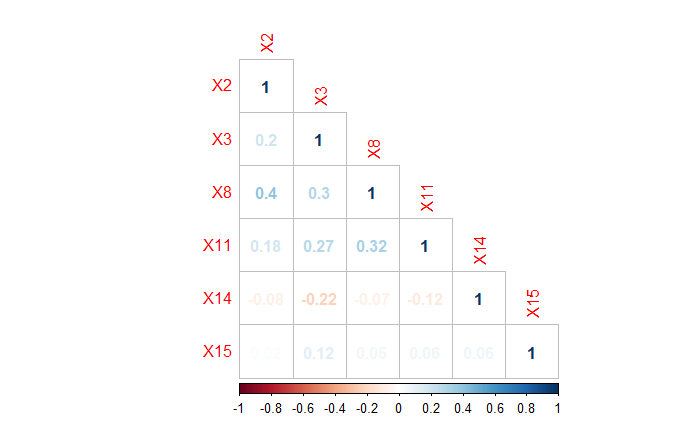

```r
corrplot(cor(numeric_columns), method = "number", type = "lower")
```

Generally weak correlations between numeric variables. Strongest correlations are between X8 and X2 at 0.4, and between X11 and X8 at 0.32. X15 appears not to correlate well with any variable.

independency test for all variables against target variable

```r
sapply(imp_data[, -16], function(x) round(chisq.test(x, imp_data$X16)$p.value, 4))
```

```
    X1     X2     X3     X4     X5     X6     X7     X8     X9    X10    X11    X12    X13    X14    X15
0.4881 0.1549 0.1154 0.0000 0.0000 0.0000 0.0000 0.0000 0.0000 0.0000 0.0000 0.4509 0.0101 0.0068 0.0007
```

These results suggest that columns X1, X2, X3, and X12 are independent of column X16, whereas the rest show a significant relationship with column X16

```r
colnames(numeric_columns)
```

```
[1] "X2"  "X3"  "X8"  "X11" "X14" "X15"
```

scale numeric columns

```r
imp_data$X2 <- scale(imp_data$X2)
imp_data$X3 <- scale(imp_data$X3)
imp_data$X8 <- scale(imp_data$X8)
imp_data$X11 <- scale(imp_data$X11)
imp_data$X14 <- scale(imp_data$X14)
imp_data$X15 <- scale(imp_data$X15)
```

**Task 3**

Create matrices of data

```r
X <- data.matrix(subset(imp_data, select = -16))
Y <- as.double(as.matrix(imp_data[ , 16]))
```

```r
head(X)
```

```
  X1          X2         X3 X4 X5 X6 X7          X8 X9 X10        X11 X12 X13        X14         X15
1  1 -0.06374394 -0.9559198  1  1  1  1 -0.29087163  1   1 -0.2878917   0   1  0.1090812 -0.19527168
2  2  2.28165946 -0.0600070  1  1  2  2  0.24401343  1   1  0.7402929   0   1 -0.8133488 -0.08778820
3  2 -0.59701993 -0.8554811  1  1  2  2 -0.21616701  1   0 -0.4935286   0   1  0.5615940 -0.03711741
4  1 -0.31648138 -0.6465687  1  1  1  1  0.45617454  1   1  0.5346560   1   1 -0.4826664 -0.19469588
5  1 -0.96180430  0.1740151  1  1  1  1 -0.15341513  1   0 -0.4935286   0   2 -0.3666374 -0.19527168
6  1  0.04156332 -0.1524106  1  1  3  1  0.08265146  1   0 -0.4935286   1   1  1.0257097 -0.19527168
```

Separate Train (first 590 rows) and Test (final 100 rows) data

```r
X_train <- X[1:590, ]
Y_train <- Y[1:590]
X_test <- X[591:nrow(X), ]
Y_test <- Y[591:length(Y)]
```

**Task 4 - Ridge Regression Model**

Create Ridge model setting alpha to 0

```r
set.seed(123)
cv.ridge <- cv.glmnet(X_train, Y_train, family = "binomial", parellel = TRUE, standardize = TRUE, type.measure = "auc", alpha = 0)
```

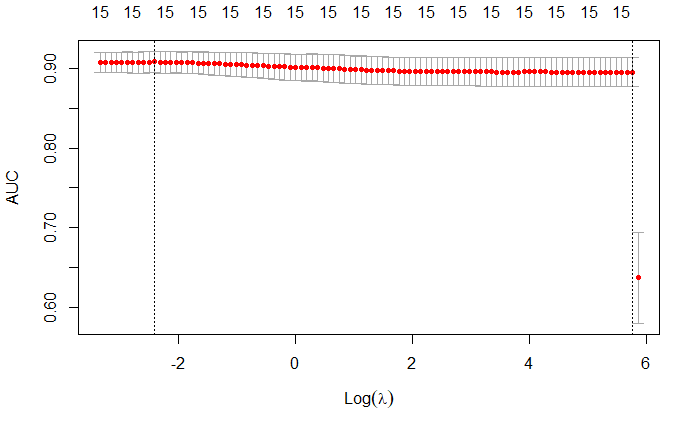

```r
plot(cv.ridge)
```

```r
( lambda.ridge <- cv.ridge$lambda.min )
```

```
[1] 0.08939105
```

```r
y_pred_ridge <- as.numeric(predict.glmnet(cv.ridge$glmnet.fit, newx = X_test, s = lambda.ridge)>0.5)
```

```r
( cm_ridge <- confusionMatrix(as.factor(y_pred_ridge), as.factor(Y_test), mode = "everything", positive = "1") )
```

```
Confusion Matrix and Statistics

          Reference
Prediction  0  1
         0 86  8
         1  0  6

               Accuracy : 0.92
                 95% CI : (0.8484, 0.9648)
    No Information Rate : 0.86
    P-Value [Acc > NIR] : 0.04921

                  Kappa : 0.5633

 Mcnemar's Test P-Value : 0.01333

            Sensitivity : 0.4286
            Specificity : 1.0000
         Pos Pred Value : 1.0000
         Neg Pred Value : 0.9149
              Precision : 1.0000
                 Recall : 0.4286
                     F1 : 0.6000
             Prevalence : 0.1400
         Detection Rate : 0.0600
   Detection Prevalence : 0.0600
      Balanced Accuracy : 0.7143

       'Positive' Class : 1
```

**Task 5- Ridge Regression Model**

Calculate log odds for each variable with respect to target variable

```r
coefs.ridge <- as.matrix(coef(cv.ridge, s = lambda.ridge))
for (coef in 2:nrow(coefs.ridge)) {
  log_odd <- exp(coefs.ridge[coef])
  prob_increase <- round(log_odd *100 - 100, 2)
  if (prob_increase == 0) {
    print(paste("column", colnames(imp_data[coef-1], "has no effect on the probabilty that the class attribute (column X16) value will be TRUE or FALSE")))
  } else if (prob_increase > 0) {
    print(paste("For every unit increase of column", colnames(imp_data[coef-1]), ", the probability that the class atribute value (column X16) will be TRUE increases by", prob_increase, "%."))
  } else {
    print(paste("For every unit increase of column", colnames(imp_data[coef-1]), ", the probability that the class atribute value (column X16) will be TRUE decreases by", abs(prob_increase), "%."))
  }
}
```

```
[1] "For every unit increase of column X1 , the probability that the class atribute value (column X16) will be TRUE increases by 9.79 %."
[1] "For every unit increase of column X2 , the probability that the class atribute value (column X16) will be TRUE increases by 4.5 %."
[1] "For every unit increase of column X3 , the probability that the class atribute value (column X16) will be TRUE increases by 8.36 %."
[1] "For every unit increase of column X4 , the probability that the class atribute value (column X16) will be TRUE decreases by 13.14 %."
[1] "For every unit increase of column X5 , the probability that the class atribute value (column X16) will be TRUE decreases by 13.13 %."
[1] "For every unit increase of column X6 , the probability that the class atribute value (column X16) will be TRUE decreases by 4.69 %."
[1] "For every unit increase of column X7 , the probability that the class atribute value (column X16) will be TRUE decreases by 2.33 %."
[1] "For every unit increase of column X8 , the probability that the class atribute value (column X16) will be TRUE increases by 23.72 %."
[1] "For every unit increase of column X9 , the probability that the class atribute value (column X16) will be TRUE increases by 541.53 %."
[1] "For every unit increase of column X10 , the probability that the class atribute value (column X16) will be TRUE increases by 98.81 %."
[1] "For every unit increase of column X11 , the probability that the class atribute value (column X16) will be TRUE increases by 34.41 %."
[1] "For every unit increase of column X12 , the probability that the class atribute value (column X16) will be TRUE decreases by 3.52 %."
[1] "For every unit increase of column X13 , the probability that the class atribute value (column X16) will be TRUE increases by 2.44 %."
[1] "For every unit increase of column X14 , the probability that the class atribute value (column X16) will be TRUE decreases by 10.64 %."
[1] "For every unit increase of column X15 , the probability that the class atribute value (column X16) will be TRUE increases by 27.52 %."
```

**Task 4 - Lasso Regression Model**

Create Lasso model setting alpha to 1

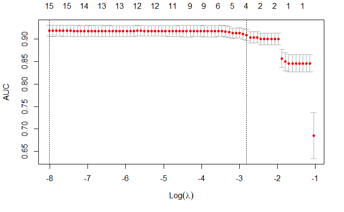

```r
cv.lasso <- cv.glmnet(X_train, Y_train, family = "binomial", parellel = TRUE, standardize = TRUE, type.measure = "auc", alpha = 1)

plot(cv.lasso)
```

```r
( lambda.lasso <- cv.lasso$lambda.min )
```

```
[1] 0.0003288142
```

```r
y_pred_lasso <- as.numeric(predict.glmnet(cv.lasso$glmnet.fit, newx = X_test, s = lambda.lasso)>0.5)
head(y_pred_lasso)
```

```
[1] 1 1 0 0 0 0
```

```r
( cm_lasso <-confusionMatrix(as.factor(y_pred_lasso), as.factor(Y_test), mode = "everything", positive = "1") )
```

```
Confusion Matrix and Statistics

          Reference
Prediction  0  1
         0 86  8
         1  0  6

               Accuracy : 0.92
                 95% CI : (0.8484, 0.9648)
    No Information Rate : 0.86
    P-Value [Acc > NIR] : 0.04921

                  Kappa : 0.5633

 Mcnemar's Test P-Value : 0.01333

            Sensitivity : 0.4286
            Specificity : 1.0000
         Pos Pred Value : 1.0000
         Neg Pred Value : 0.9149
              Precision : 1.0000
                 Recall : 0.4286
                     F1 : 0.6000
             Prevalence : 0.1400
         Detection Rate : 0.0600
   Detection Prevalence : 0.0600
      Balanced Accuracy : 0.7143

       'Positive' Class : 1
```

**Task 5 - Lasso Regression Model**

Calculate log odd for each variable with respect to target variable

```r
coefs.lasso <- as.matrix(coef(cv.lasso, s = lambda.lasso))
for (coef in 2:nrow(coefs.lasso)) {
  log_odd <- exp(coefs.lasso[coef])
  prob_increase <- round(log_odd *100 - 100, 2)
  if (prob_increase == 0) {
    print(paste("Column", colnames(imp_data[coef-1]), "has no effect on the probability that the class attribute value (column X16) will be TRUE or FALSE."))
  } else if (prob_increase > 0) {
    print(paste("For every unit increase of column", colnames(imp_data[coef-1]), ", the probability that the class atribute value (column X16) will be TRUE increases by", prob_increase, "%."))
  } else {
    print(paste("For every unit increase of column", colnames(imp_data[coef-1]), ", the probability that the class atribute value (column X16) will be TRUE decreases by", abs(prob_increase), "%."))
  }
}
```

```
[1] "For every unit increase of column X1 , the probability that the class atribute value (column X16) will be TRUE increases by 17.5 %."
[1] "For every unit increase of column X2 , the probability that the class atribute value (column X16) will be TRUE decreases by 4.41 %."
[1] "For every unit increase of column X3 , the probability that the class atribute value (column X16) will be TRUE decreases by 1.36 %."
[1] "For every unit increase of column X4 , the probability that the class atribute value (column X16) will be TRUE decreases by 27.37 %."
[1] "Column X5 has no effect on the probability that the class attribute value (column X16) will be TRUE or FALSE."
[1] "For every unit increase of column X6 , the probability that the class atribute value (column X16) will be TRUE decreases by 6.63 %."
[1] "For every unit increase of column X7 , the probability that the class atribute value (column X16) will be TRUE increases by 0.32 %."
[1] "For every unit increase of column X8 , the probability that the class atribute value (column X16) will be TRUE increases by 37.14 %."
[1] "For every unit increase of column X9 , the probability that the class atribute value (column X16) will be TRUE increases by 2765.51 %."
[1] "For every unit increase of column X10 , the probability that the class atribute value (column X16) will be TRUE increases by 103.09 %."
[1] "For every unit increase of column X11 , the probability that the class atribute value (column X16) will be TRUE increases by 66.84 %."
[1] "For every unit increase of column X12 , the probability that the class atribute value (column X16) will be TRUE decreases by 20.21 %."
[1] "For every unit increase of column X13 , the probability that the class atribute value (column X16) will be TRUE increases by 62.3 %."
[1] "For every unit increase of column X14 , the probability that the class atribute value (column X16) will be TRUE decreases by 18.85 %."
[1] "For every unit increase of column X15 , the probability that the class atribute value (column X16) will be TRUE increases by 984.28 %."
```

AUC values for each regression model

```r
max(cv.ridge$cvm)
```

```
[1] 0.908114
```

```r
max(cv.lasso$cvm)
```

```
[1] 0.9189988
```

Here we can see that the lasso model has a slightly higher mean cross-validated error. In this case, as AUC was selected as the measure, this cvm value is the AUC. Therefore, the lasso model is slightly better. However, this provides no additional benefit over the ridge model in practice as shown by identical confusion matrices.

**Task 6**

Calculate loss/gain

```r
cm_lasso$table
```

```
          Reference
Prediction  0  1
         0 86  8
         1  0  6
```

```r
# 100 for true positive = 6
# -20 for false positive = 0

money <- (100 * cm_lasso$table[2,2]) - (20 * cm_lasso$table[2,1])
print(paste("This model will have won a total of", money, "Euros"))
```

```
[1] "This model will have won a total of 600 Euros"
```